# An exploration of factors affecting life expectancy in world countries

## Preliminary Wrangling

My dataset will require quite a bit of extra wrangling, but I'm hoping the results will be interesting and worth the effort. I'm pulling primarily from Gapminder, and I'll be joining several tables from this dataset. We will look at population, healthcare spending and income per capita. I am also pulling data on which countries have universal healthcare, and also what continents countries are in from the respective Wikipedia pages. This categorical information will be another way to slice our data to look for conclusions.

```python
# import all packages
import matplotlib.pyplot as plt
from matplotlib import rcParams
rcParams['font.family'] = 'serif'
import pandas as pd
import numpy as np
import seaborn as sb
import statsmodels.api as sm
from bs4 import NavigableString, BeautifulSoup
import os

# set plots to be embedded inline
%matplotlib inline
```

```python
# CSV IMPORTATION *******************
# Gapminder tables have a row of column headers and an index colum

#life expectancy
le_filename = 'data/life_expectancy_years.csv'
le = pd.read_csv(le_filename, header=0, index_col=0)

#inflation adjusted income per person
ic_filename = 'data/income_per_person_gdppercapita_ppp_inflation_adjusted.csv'
ic = pd.read_csv(ic_filename, header=0, index_col=0)

#total health spending per person
th_filename = 'data/total_health_spending_per_person_international_dollar.csv'
th = pd.read_csv(th_filename, header=0, index_col=0)

#total population
pp_filename = 'data/population_total.csv'
pp = pd.read_csv(pp_filename, header=0, index_col=0)

print(le.index.values)
```

```
['Afghanistan' 'Albania' 'Algeria' 'Andorra' 'Angola'
 'Antigua and Barbuda' 'Argentina' 'Armenia' 'Australia' 'Austria'
 'Azerbaijan' 'Bahamas' 'Bahrain' 'Bangladesh' 'Barbados' 'Belarus'
 'Belgium' 'Belize' 'Benin' 'Bhutan' 'Bolivia' 'Bosnia and Herzegovina'
 'Botswana' 'Brazil' 'Brunei' 'Bulgaria' 'Burkina Faso' 'Burundi'
 'Cambodia' 'Cameroon' 'Canada' 'Cape Verde' 'Central African Republic'
 'Chad' 'Chile' 'China' 'Colombia' 'Comoros' 'Congo, Dem. Rep.'
 'Congo, Rep.' 'Costa Rica' "Cote d'Ivoire" 'Croatia' 'Cuba' 'Cyprus'
 'Czech Republic' 'Denmark' 'Djibouti' 'Dominica' 'Dominican Republic'
 'Ecuador' 'Egypt' 'El Salvador' 'Equatorial Guinea' 'Eritrea' 'Estonia'
 'Ethiopia' 'Fiji' 'Finland' 'France' 'Gabon' 'Gambia' 'Georgia' 'Germany'
 'Ghana' 'Greece' 'Grenada' 'Guatemala' 'Guinea' 'Guinea-Bissau' 'Guyana'
 'Haiti' 'Honduras' 'Hungary' 'Iceland' 'India' 'Indonesia' 'Iran' 'Iraq'
 'Ireland' 'Israel' 'Italy' 'Jamaica' 'Japan' 'Jordan' 'Kazakhstan'
 'Kenya' 'Kiribati' 'Kuwait' 'Kyrgyz Republic' 'Lao' 'Latvia' 'Lebanon'
 'Lesotho' 'Liberia' 'Libya' 'Lithuania' 'Luxembourg' 'Madagascar'
 'Malawi' 'Malaysia' 'Maldives' 'Mali' 'Malta' 'Marshall Islands'
 'Mauritania' 'Mauritius' 'Mexico' 'Micronesia, Fed. Sts.' 'Moldova'
 'Mongolia' 'Montenegro' 'Morocco' 'Mozambique' 'Myanmar' 'Namibia'
 'Nepal' 'Netherlands' 'New Zealand' 'Nicaragua' 'Niger' 'Nigeria'
 'North Korea' 'North Macedonia' 'Norway' 'Oman' 'Pakistan' 'Palestine'
 'Panama' 'Papua New Guinea' 'Paraguay' 'Peru' 'Philippines' 'Poland'
 'Portugal' 'Qatar' 'Romania' 'Russia' 'Rwanda' 'Samoa'
 'Sao Tome and Principe' 'Saudi Arabia' 'Senegal' 'Serbia' 'Seychelles'
 'Sierra Leone' 'Singapore' 'Slovak Republic' 'Slovenia' 'Solomon Islands'
 'Somalia' 'South Africa' 'South Korea' 'South Sudan' 'Spain' 'Sri Lanka'
 'St. Lucia' 'St. Vincent and the Grenadines' 'Sudan' 'Suriname'
 'Swaziland' 'Sweden' 'Switzerland' 'Syria' 'Tajikistan' 'Tanzania'
 'Thailand' 'Timor-Leste' 'Togo' 'Tonga' 'Trinidad and Tobago' 'Tunisia'
 'Turkey' 'Turkmenistan' 'Uganda' 'Ukraine' 'United Arab Emirates'
 'United Kingdom' 'United States' 'Uruguay' 'Uzbekistan' 'Vanuatu'
 'Venezuela' 'Vietnam' 'Yemen' 'Zambia' 'Zimbabwe']
```

Next we will gather our list of countries that have universal healthcare. The Soup process for this one will be fairly simple - all our data has the same unique class. A few extra entries will be included but that's ok, they won't match a country so we can clean them as we merge.

```python
# List of countries that have universal healthcare, from the Wikipedia page
uhc_list = []
with open(os.path.join('data/uhc_countries.html')) as file:
    soup = BeautifulSoup(file, 'lxml')
    for item in soup.find_all('span', class_='toctext'):
        uhc_list.append(item.text)

    # remove a couple of lines of unrelated text that have the same tag
    uhc_list = uhc_list[:-2]

    # print our list to test our work.
    print(uhc_list)
```

```
['Africa', 'Algeria', 'Botswana', 'Burkina Faso', 'Egypt', 'Ghana', 'Mauritius', 'Morocco', 'Rwanda', 'Seychelles', 'South Africa', 'Tunisia', 'Americas', 'Argentina', 'The Bahamas', 'Brazil', 'Canada', 'Chile', 'Colombia', 'Costa Rica', 'Cuba', 'Mexico', 'Peru', 'Trinidad and Tobago', 'United State…
```

Next we will make a list of lists of country/continent pairs. Below is a picture of the relative structure of our HTML. This is what we need to navigate to get our country and continents paired. Essentially what we'll look for is a continent name, and then we'll look for the next `<li>` tag below it. We'll need to progress through siblings, rather than parents/children.

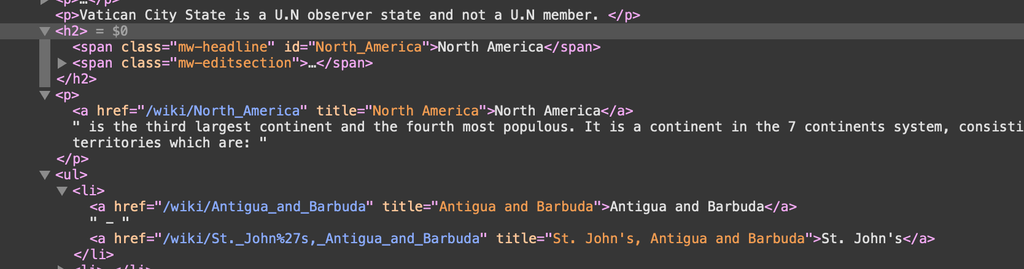

```python
# List of countries and continents, from Wikipedia
# I don't use BeautifulSoup much so prepare for a lot of comments.
countries_list = []
with open(os.path.join('data/countries.html')) as file:
    soup = BeautifulSoup(file, 'lxml')

    # first, we loop through to find each continent.
    for continent in soup.find_all('span', class_='mw-headline')[0:7]:
        # we will change the name "Oceania/Australia" to just "Oceania"
        # which is more universally accepted and standard.
        if (continent.text == "Oceania/Australia"):
            continent_name = "Oceania"
        else:
            continent_name = continent.text

        # for each continent, we will keep finding siblings until we find
        # a header tag that indicates we've hit the next continent
        for sibling in continent.parent.next_siblings:
            # Soup errs with attribute checks on NavigableString objects
            if isinstance(sibling, NavigableString) == False:
                # a header means we're done with the current continent
                if sibling.name == "h2":
                    break

                # find all <li> tags in children of current pointer location
                # and if it has a link, store the text from it.
                for country in sibling.find_all('li'):
                    if country.a != None:
                        country_name = country.a.text
                        countries_list.append([country_name, continent_name])

# print a test slice of our list of lists.
print(len(countries_list), countries_list[-30:])
```

```
232 [['Guyana', 'South America'], ['Paraguay', 'South America'], ['Peru', 'South America'], ['South Georgia and the South Sandwich Islands', 'South America'], ['Suriname', 'South America'], ['Uruguay', 'South America'], ['Venezuela', 'South America'], ['Australia', 'Oceania'], ['Federated States of …
```

```python
le.head(2), th.head(2), pp.head(2)
```

```
(             1800  1801  1802  1803  1804  1805  1806  1807  1808  1809  ...  \
 country                                                                  ...
 Afghanistan  28.2  28.2  28.2  28.2  28.2  28.2  28.1  28.1  28.1  28.1  ...
 Albania      35.4  35.4  35.4  35.4  35.4  35.4  35.4  35.4  35.4  35.4  ...

              2091  2092  2093  2094  2095  2096  2097  2098  2099  2100
 country
 Afghanistan  76.5  76.6  76.7  76.9  77.0  77.1  77.3  77.4  77.5  77.7
 Albania      87.4  87.5  87.6  87.7  87.8  87.9  88.0  88.1  88.2  88.3

 [2 rows x 301 columns],
               1995   1996   1997   1998   1999   2000   2001   2002   2003  \
 country
 Afghanistan    NaN    NaN    NaN    NaN    NaN    NaN    NaN   22.1   29.7
 Albania      106.0  146.0  156.0  184.0  225.0  266.0  279.0  303.0  326.0

               2004   2005   2006   2007   2008   2009   2010
 country
 Afghanistan   32.1   35.6   36.2   40.4   38.3   45.6   44.5
 Albania      380.0  407.0  451.0  494.0  557.0  592.0  577.0  ,
                 1800     1801     1802     1803     1804     1805     1806  \
 country
 Afghanistan  3280000  3280000  3280000  3280000  3280000  3280000  3280000
 Albania       400000   402000   404000   405000   407000   409000   411000

                 1807     1808     1809  ...      2091      2092      2093  \
 country                                 ...
 Afghanistan  3280000  3280000  3280000  ...  76600000  76400000  76300000
 Albania       413000   414000   416000  ...   1330000   1300000   1270000

                  2094      2095      2096      2097      2098      2099  \
 country
 Afghanistan  76100000  76000000  75800000  75600000  75400000  75200000
 Albania       1250000   1220000   1190000   1170000   1140000   1110000

                  2100
 country
 Afghanistan  74900000
 Albania       1090000

 [2 rows x 301 columns])
```

We can see that the data is all by year, and we do see NaNs for some countries for some years. We'll need to pick a year in order to perform 2d analysis on this data. Let's find the most modern year that has the most data (fewest NaNs) for all the variables I'd like to explore.

```python
HIGH = '2015'
LOW = '2005'

# First we get a count of NaNs by year
nan_list = le.loc[:,LOW:HIGH].isna().sum() \
    + ic.loc[:,LOW:HIGH].isna().sum() \
    + th.loc[:,LOW:HIGH].isna().sum() \
    + pp.loc[:,LOW:HIGH].isna().sum() \

# then make a list of only columns with the min NaN count...
nan_list_mins = nan_list[nan_list == nan_list.min()]

# if we return the last rows index, that should mean the most recent year
# since our data is already sorted by year
year = str(nan_list_mins.tail(1).index[0])
year
```

```
'2009'
```

Now we need to drop all years from all gapminder tables except the selected year, then change the names from the year into more helpful values.

```python
# This function strips all but one year, but could easily be modified
# to keep a list of years if a 3d analysis is needed.
def keep_one_year(df, year):
    year_mask = (df.columns.values == year)
    return df.loc[:, year_mask]

# Now we apply it to each table
le = keep_one_year(le, year)
ic = keep_one_year(ic, year)
th = keep_one_year(th, year)
pp = keep_one_year(pp, year)

le.rename(columns = {year:'le'}, inplace = True)
ic.rename(columns = {year:'ic'}, inplace = True)
th.rename(columns = {year:'th'}, inplace = True)
pp.rename(columns = {year:'pp'}, inplace = True)

# test a table
le.head()
```

| country | le |
| --- | --- |
| Afghanistan | 59.3 |
| Albania | 77.5 |
| Algeria | 76.1 |
| Andorra | 82.2 |
| Angola | 59.1 |

We are finally ready to merge! We will do a left join because the life expectancy data is the piont of the study, so that field is required. I'll handle nulls in the other columns as I go. I have a validation step to make sure everybody is on board.

```python
#df = []
df_init = le.join([ic, th, pp], how='left')

# for a validation spot check, I'm essentially building a row of the joined table
# from the individual tables and then comparing it to the master table.
TEST_COUNTRY = 'Angola'
spot_check = [le.loc[TEST_COUNTRY].values[0], ic.loc[TEST_COUNTRY].values[0], \
              th.loc[TEST_COUNTRY].values[0], pp.loc[TEST_COUNTRY].values[0]]
if np.array_equal(np.array(df_init.loc[TEST_COUNTRY].values), np.array(spot_check)):
    print("Master table data validated")
else:
    print("Error in master table construction")
```

```
Master table data validated
```

Now we need to add our list of universal healthcare countries to the list. I will need to change some of the names by hand because the country names aren't stable and differ in use of unicode, etc., but let's take of the ones that are an exact match and see what's left.

```python
df_init['uhc'] = False
unmatched = []
for name in uhc_list:
    if name in df_init.index.values:
        df_init.loc[name, 'uhc'] = True
    else:
        unmatched.append(name)
print("UNMATCHED ITEMS")
print(unmatched)
print("UNMATCHED COUNTRY LIST")
print(df_init[df_init.uhc == False].index.values)
```

```
UNMATCHED ITEMS
['Africa', 'Americas', 'The Bahamas', 'Asia', 'Hong Kong', 'Macau', "People's Republic of China", 'Taiwan', 'Europe', 'Guernsey / Jersey', 'Isle of Man', 'Russia and Soviet Union', 'England', 'Northern Ireland', 'Scotland', 'Wales', 'Oceania']
UNMATCHED COUNTRY LIST
['Afghanistan' 'Andorra' 'Angola' 'Antigua and Barbuda' 'Armenia'
 'Azerbaijan' 'Bahamas' 'Bahrain' 'Bangladesh' 'Barbados' 'Belarus'
 'Belize' 'Benin' 'Bolivia' 'Bosnia and Herzegovina' 'Brunei' 'Bulgaria'
 'Burundi' 'Cambodia' 'Cameroon' 'Cape Verde' 'Central African Republic'
 'Chad' 'China' 'Comoros' 'Congo, Dem. Rep.' 'Congo, Rep.' "Cote d'Ivoire"
 'Cyprus' 'Djibouti' 'Dominica' 'Dominican Republic' 'Ecuador'
 'El Salvador' 'Equatorial Guinea' 'Eritrea' 'Estonia' 'Ethiopia' 'Fiji'
 'Gabon' 'Gambia' 'Grenada' 'Guatemala' 'Guinea' 'Guinea-Bissau' 'Guyana'
 'Haiti' 'Honduras' 'Hungary' 'Indonesia' 'Iran' 'Iraq' 'Jamaica' 'Jordan'
 'Kazakhstan' 'Kenya' 'Kiribati' 'Kuwait' 'Kyrgyz Republic' 'Lao' 'Latvia'
 'Lebanon' 'Lesotho' 'Liberia' 'Libya' 'Lithuania' 'Madagascar' 'Malawi'
 'Malaysia' 'Mali' 'Malta' 'Marshall Islands' 'Mauritania'
 'Micronesia, Fed. Sts.' 'Moldova' 'Mongolia' 'Montenegro' 'Mozambique'
 'Myanmar' 'Namibia' 'Nepal' 'Nicaragua' 'Niger' 'Nigeria' 'North Korea'
 'North Macedonia' 'Oman' 'Pakistan' 'Palestine' 'Panama'
 'Papua New Guinea' 'Paraguay' 'Philippines' 'Poland' 'Qatar' 'Russia'
 'Samoa' 'Sao Tome and Principe' 'Saudi Arabia' 'Senegal' 'Sierra Leone'
 'Slovak Republic' 'Slovenia' 'Solomon Islands' 'Somalia' 'South Korea'
 'South Sudan' 'St. Lucia' 'St. Vincent and the Grenadines' 'Sudan'
 'Suriname' 'Swaziland' 'Syria' 'Tajikistan' 'Tanzania' 'Timor-Leste'
 'Togo' 'Tonga' 'Turkey' 'Turkmenistan' 'Uganda' 'Ukraine'
 'United Arab Emirates' 'Uruguay' 'Uzbekistan' 'Vanuatu' 'Venezuela'
 'Vietnam' 'Yemen' 'Zambia' 'Zimbabwe']
```

Our matching algorithm did a pretty good job. I see the The Bahamas, The UK, and China didn't match. Let's fix those by hand.

```python
df_init.loc[['Bahamas', 'China', 'United Kingdom'], 'uhc'] = True
print("Sum of countries with universal healthcare in our study is:", df_init.uhc.sum())
```

```
Sum of countries with universal healthcare in our study is: 58
```

Our last merge is to add the continent information. We'll do it in essentially the same manner - take care of most of these programatically and then tweak what we need to by hand.

```python
df_init['continent'] = ''
unmatched = []
for country, continent in countries_list:
    if country in df_init.index.values:
        df_init.loc[country, 'continent'] = continent
        # print(country, "WAS a match, ", df.loc[name].continent)
    else:
        # print(country, " was not a match")
        unmatched.append(country)
print(f"There are {df_init[df_init.continent == ''].shape[0]} countries without a continent assigned:")
print(df_init[df_init.continent == ''].index.values)
```

```
There are 15 countries without a continent assigned:
['Bahamas' 'Congo, Dem. Rep.' 'Congo, Rep.' "Cote d'Ivoire" 'Gambia'
 'Ireland' 'Kyrgyz Republic' 'Lao' 'Micronesia, Fed. Sts.'
 'Sao Tome and Principe' 'Slovak Republic' 'St. Lucia'
 'St. Vincent and the Grenadines' 'Timor-Leste' 'United States']
```

```python
africa = ['Congo, Dem. Rep.', 'Congo, Rep.', "Cote d'Ivoire", \
          'Gambia', 'Sao Tome and Principe']
asia = ['Lao', 'Kyrgyz Republic']
europe = ['Ireland', 'Slovak Republic']
north_america = ['United States', 'Bahamas', 'Timor-Leste', 'St. Vincent and the Grenadines', 'St. Lucia']
oceania = ['Micronesia, Fed. Sts.']

df_init.loc[africa, 'continent'] = 'Africa'
df_init.loc[asia, 'continent'] = 'Asia'
df_init.loc[europe, 'continent'] = 'Europe'
df_init.loc[north_america, 'continent'] = 'North America'
df_init.loc[oceania, 'continent'] = 'Oceania'

if df_init[df_init.continent == ''].shape[0] == 0:
    print("Success - all countries have a continent")
else:
    print("There's been an error")
    print(f"There are {df_init[df_init.continent == ''].shape[0]} countries without a continent assigned:")
    print(df_init[df_init.continent == ''].index.values)
```

```
Success - all countries have a continent
```

Now let's save a copy of our cleaned data and also make a backup in memory before we begin further cleaning and analysis.

```python
df_init.to_csv ('data/gapminder_data_wrangled.csv', index = True, header=True)

df = df_init.copy()

df.head(), df.info(), df.describe()
```

```
<class 'pandas.core.frame.DataFrame'>
Index: 187 entries, Afghanistan to Zimbabwe
Data columns (total 6 columns):
 #   Column     Non-Null Count  Dtype
---  ------     --------------  -----
 0   le         187 non-null    float64
 1   ic         187 non-null    float64
 2   th         182 non-null    float64
 3   pp         187 non-null    int64
 4   uhc        187 non-null    bool
 5   continent  187 non-null    object
dtypes: bool(1), float64(3), int64(1), object(1)
memory usage: 8.9+ KB
```

```
(               le       ic      th        pp    uhc continent
 country
 Afghanistan  59.3   1500.0    45.6  28400000  False      Asia
 Albania      77.5   9530.0   592.0   2970000   True    Europe
 Algeria      76.1  12700.0   365.0  35300000   True    Africa
 Andorra      82.2  41700.0  3400.0     84500  False    Europe
 Angola       59.1   6290.0   297.0  22500000  False    Africa,
 None,
                le             ic           th            pp
 count  187.000000     187.000000   182.000000  1.870000e+02
 mean    70.210695   16013.283422  1035.356593  3.655034e+07
 std      8.705072   18255.848570  1375.068088  1.374308e+08
 min     44.900000     615.000000    15.900000  5.630000e+04
 25%     63.300000    3185.000000   136.750000  2.075000e+06
 50%     72.900000    9380.000000   478.500000  8.150000e+06
 75%     76.750000   21550.000000  1272.500000  2.430000e+07
 max     83.100000  113000.000000  7960.000000  1.360000e+09)
```

### What is the structure of your dataset?

> A LOT of cleaning and wrangling has been done at this point to grind this table to a dataframe of 187 rows and 6 columns, each of which is pulled form a separate table or scraped from a separate webpage. The data is 4 numeric variables (3 float, 1 int), 1 bool, 1 string. There are 5 missing values from one float table, the rest are fully non-null

### What is/are the main feature(s) of interest in your dataset?

> I'll be looking at the relationship between life expectancy and other variables.

### What features in the dataset do you think will help support your investigation into your feature(s) of interest?

> I can look at life expectancy through a few different lenses - the overall money spent on health, the government's participation in healthcare spending, the location of the country, and how wealthy it is. These are a broader set of indicators than, say, looking at only economic factors. The categorical data I've added will help me look at the data via violin and facet charts.

## Univariate Exploration

> Let's look at our most important variable, life expectancy.

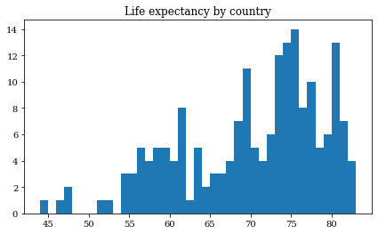

```python
# for all these histograms I'd like to determine my bins programmatically,
# because that way I can ensure I won't lose any outlier data by accident.
# I will keep the bin size as a constant however based on the look of the graph
BIN_SIZE = 1

plt.figure(figsize = [7, 4])
bins_list = np.arange(int(df['le'].min()), int(df['le'].max()) + BIN_SIZE, BIN_SIZE)
plt.title("Life expectancy by country")
plt.hist(data = df, x = 'le', bins=bins_list);
```

> We see a moderately right shifted unimodal distribution, suggesting a logarithmic effect that we'd expect thinking about the human lifespan. The most like an outlier in our data is the first four values, although those aren't so far off that they really skew our visualization. Let's look at income next.

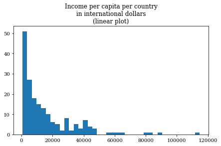

```python
BIN_SIZE = 3000

plt.figure(figsize = [7, 4])
bins_list = np.arange(int(df['ic'].min()), int(df['ic'].max()) + BIN_SIZE, BIN_SIZE)
plt.title("Income per capita per country\nin international dollars\n(linear plot)")
plt.hist(data = df, x = 'ic', bins=bins_list);
```

The extreme left shift of this data suggests an exponential distribution. Let's make a log transformation.

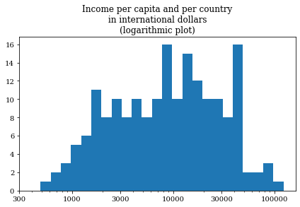

```python
BIN_SIZE = .1

plt.figure(figsize = [7, 4])
bins_list = 10 ** np.arange(np.log10(df['ic'].min()) - BIN_SIZE, np.log10(df['ic'].max()) + BIN_SIZE, BIN_SIZE)
plt.hist(data = df, x = 'ic', bins = bins_list)
plt.xscale('log')
plt.title("Income per capita and per country\nin international dollars\n(logarithmic plot)")
tick_locs = [300, 1000, 3000, 10000, 30000, 100000]
plt.xticks(tick_locs, tick_locs);
```

This gives us a more detailed and informative plot. Let's look our other variables in both linear and logarithmic plots, since I suspect total healthcare spending and also income will be exponentially increasing.

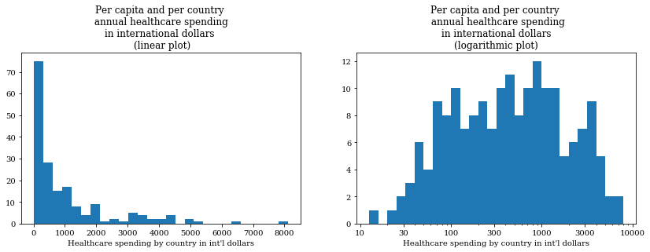

```python
plt.figure(figsize = [14, 4])

#### NON-LOG GRAPH
plt.subplot(1,2,1)
BIN_SIZE = 300
bins_list = np.arange(int(df['th'].min()), int(df['th'].max()) + BIN_SIZE, BIN_SIZE)
plt.hist(data = df, x = 'th', bins=bins_list);
plt.title("Per capita and per country \n annual healthcare spending \n\
in international dollars \n (linear plot)")
plt.xlabel("Healthcare spending by country in int'l dollars")

### LOG TRANSFORMATION GRAPH
plt.subplot(1,2,2)
BIN_SIZE = .1
bins_list = 10 ** np.arange(np.log10(df['th'].min()) - BIN_SIZE, np.log10(df['th'].max()) + BIN_SIZE, BIN_SIZE)
plt.hist(data = df, x = 'th', bins = bins_list)
plt.xscale('log')
plt.title("Per capita and per country \n annual healthcare spending\n\
in international dollars\n(logarithmic plot)")
plt.xlabel("Healthcare spending by country in int'l dollars")
tick_locs = [10, 30, 100, 300, 1000, 3000, 10000]
plt.xticks(tick_locs, tick_locs);
```

As suspected, total healthcare spending is exponentially increasing. Let's look at population.

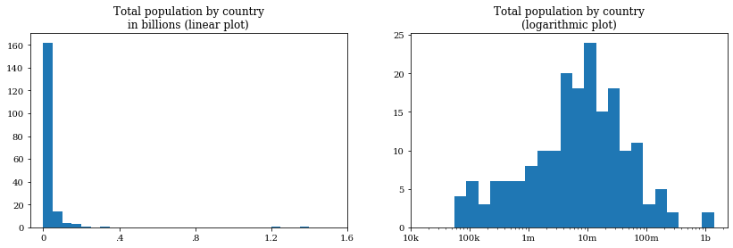

```python
plt.figure(figsize = [14, 4])

#### NON-LOG GRAPH
plt.subplot(1,2,1)
BIN_SIZE = 50000000
bins_list = np.arange(int(df['pp'].min()), int(df['pp'].max()) + BIN_SIZE, BIN_SIZE)
plt.hist(data = df, x = 'pp', bins=bins_list);
plt.title("Total population by country\nin billions (linear plot)")
tick_locs = [0, 400000000, 800000000, 1200000000, 1600000000]
ticks = ['0', '.4', '.8', '1.2', '1.6']
plt.xticks(tick_locs, ticks);
#plt.xticks(rotation = 30)

### LOG TRANSFORMATION GRAPH
plt.subplot(1,2,2)
BIN_SIZE = .2
bins_list = 10 ** np.arange(np.log10(df['pp'].min()) - BIN_SIZE, np.log10(df['pp'].max()) + BIN_SIZE, BIN_SIZE)
plt.hist(data = df, x = 'pp', bins = bins_list)
plt.xscale('log')
plt.title("Total population by country\n(logarithmic plot)")
tick_locs = [10000, 100000, 1000000, 10000000, 100000000, 1000000000]
ticks = ['10k', '100k', '1m', '10m', '100m', '1b']
plt.xticks(tick_locs, ticks);
```

Let's look at our categorical variables - continent distribution and universal healthcare. First, we'll need to make a second dataframe with an added column that is a conversion of the uhc bool into a string. Then we'll graph them both side by side.

```python
# create temp df: df_g, for graphing.
df_g = df
df_g["uhc_str"] = np.where(df_g.uhc == True, 'Universal Healthcare', 'No Universal Healthcare')
df_g.head()
```

| country | le | ic | th | pp | uhc | continent | uhc_str |
| --- | --- | --- | --- | --- | --- | --- | --- |
| Afghanistan | 59.3 | 1500.0 | 45.6 | 28400000 | False | Asia | No Universal Healthcare |
| Albania | 77.5 | 9530.0 | 592.0 | 2970000 | True | Europe | Universal Healthcare |
| Algeria | 76.1 | 12700.0 | 365.0 | 35300000 | True | Africa | Universal Healthcare |
| Andorra | 82.2 | 41700.0 | 3400.0 | 84500 | False | Europe | No Universal Healthcare |
| Angola | 59.1 | 6290.0 | 297.0 | 22500000 | False | Africa | No Universal Healthcare |

```
''
```

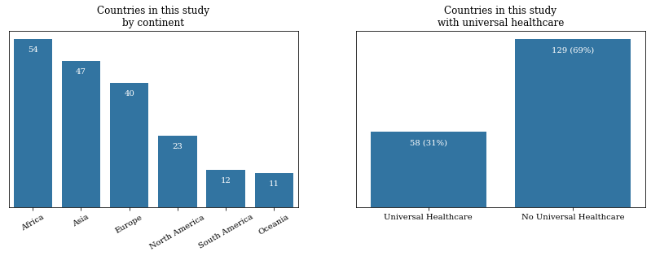

```python
# create a figure and select a color for all bars
plt.figure(figsize = [14, 4])
base_color = sb.color_palette()[0]

###### GRAPH 1
plt.subplot(1, 2, 1)
# sort by count
ax1 = sb.countplot(data = df_g, x = 'continent', color = base_color, \
                  order = df_g['continent'].value_counts().index)

# add annotations
n_points = df_g.shape[0]
cat_counts = df_g['continent'].value_counts()
locs, labels = plt.xticks() # get the current tick locations and labels
for loc, label in zip(locs, labels):
    # get the text property for the label to get the correct count
    count = cat_counts[label.get_text()]
    pct_string = '{}'.format(count)
    # print the annotation just below the top of the bar
    plt.text(loc, count-4, pct_string, ha = 'center', color = 'w')

# make label and aesthetic changes
plt.title("Countries in this study\nby continent")
plt.xticks(rotation = 30)
ax1.set(xlabel="", ylabel = "")
ax1.set_yticks([])


###### GRAPH 2
plt.subplot(1, 2, 2)
# graph is most readable with uhc first.
cat_list = ['Universal Healthcare', 'No Universal Healthcare']
ax2 = sb.countplot(data = df_g, x = 'uhc_str', color = base_color, \
                  order = cat_list)

# add annotations
n_points = df_g.shape[0]
cat_counts = df_g['uhc_str'].value_counts()
locs, labels = plt.xticks() # get the current tick locations and labels
for loc, label in zip(locs, labels):
    # get the text property for the label to get the correct count
    count = cat_counts[label.get_text()]
    pct_string = '{} ({:0.0f}%)'.format(count, 100*count/n_points)
    # print the annotation just below the top of the bar
    plt.text(loc, count-10, pct_string, ha = 'center', color = 'w')

# make label and aesthetic changes
plt.title("Countries in this study\nwith universal healthcare")
ax2.set(xlabel="", ylabel = "")
ax2.set_yticks([])
;
```

We can see about a factor of 5 in our country counts by continent, and about a factor of 2 difference in our uhc/no uhc data. These are big differences, but not so large that I think a comparison by continent or by uhc/no uhc wouldn't be valid.

## Bivariate Exploration

First, let's graph life expectancy by our two categorical variables, to ask the questions:

- Does life expectancy vary generally by continent?
- Do countries with universal healthcare tend to have higher life expectancies?

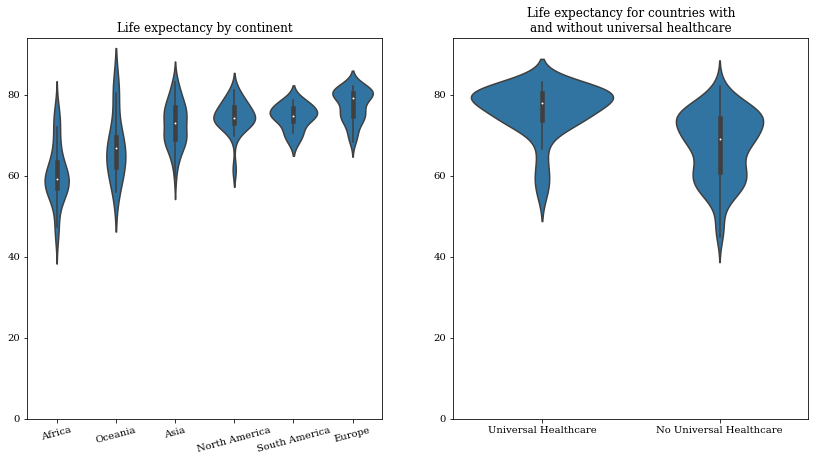

```python
plt.figure(figsize = [14, 7])
base_color = sb.color_palette()[0]

plt.subplot(1,2,1)
continent_list = ['Africa', 'Oceania', 'Asia', 'North America', 'South America', 'Europe']
vclasses = pd.api.types.CategoricalDtype(ordered = True, categories = continent_list)
df_g.continent = df_g.continent.astype(vclasses)

sb.violinplot(data = df_g, x = 'continent', y = 'le', color = base_color)
plt.xticks(rotation = 15)
plt.xlabel('')
plt.ylabel('')
plt.title('Life expectancy by continent')
plt.ylim(0,94);

plt.subplot(1,2,2)
uhc_list = ['Universal Healthcare', 'No Universal Healthcare']
vclasses = pd.api.types.CategoricalDtype(ordered = True, categories = uhc_list)
df_g.uhc_str = df_g.uhc_str.astype(vclasses)

sb.violinplot(data = df_g, x = 'uhc_str', y = 'le', color = base_color)
#plt.xticks([])
plt.xlabel('')
plt.ylabel('')
plt.title('Life expectancy for countries with\nand without universal healthcare')
plt.ylim(0,94);
```

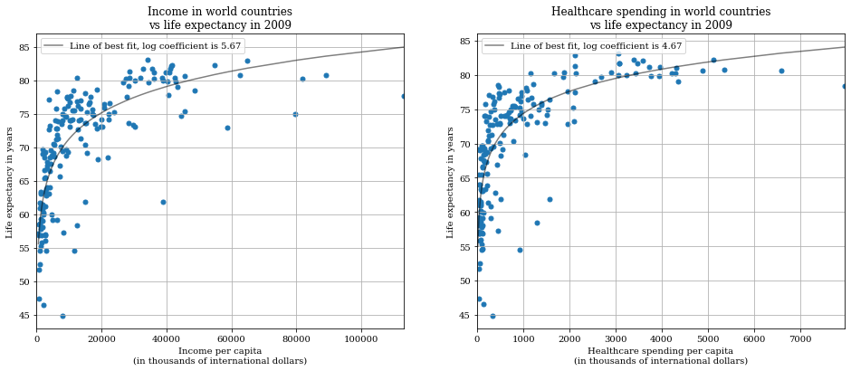

```python
df_g = df.query('th == th')

y = df_g.loc[:,'le'].values
x1 = df_g.loc[:,'ic'].values
x2 = df_g.loc[:,'th'].values

fig = plt.figure(figsize=(16, 6))

plt.subplot(1,2,1)
plt.scatter(x1, y, alpha=1, marker='.', s = 100, color=base_color)
plt.xlabel('Income per capita\n(in thousands of international dollars)')
plt.ylabel('Life expectancy in years')
plt.title('Income in world countries\nvs life expectancy in {}'.format(str(year)))
plt.grid(True)
plt.xlim(0, x1.max())

# Note: sorting is necessary to keep matplotlib from drawing multiple curves
mlog, blog = np.polyfit(np.log(x1), y, 1)
plt.plot(np.sort(x1), mlog*np.log(np.sort(x1)) + blog, \
         label='Line of best fit, log coefficient is {}'.format(str(round(mlog,2))), color='black', alpha = .5)
plt.legend();

plt.subplot(1,2,2)
plt.scatter(x2, y, alpha=1, marker='.', s = 100, color=base_color)
plt.xlabel('Healthcare spending per capita\n(in thousands of international dollars)')
plt.ylabel('Life expectancy in years')
plt.title('Healthcare spending in world countries\nvs life expectancy in {}'.format(str(year)))
plt.grid(True)
plt.xlim(0, x2.max())

# Note: sorting is necessary to keep matplotlib from drawing multiple curves
mlog, blog = np.polyfit(np.log(x2), y, 1)
plt.plot(np.sort(x2), mlog*np.log(np.sort(x2)) + blog, \
         label='Line of best fit, log coefficient is {}'.format(str(round(mlog,2))), color='black', alpha = .5)
plt.legend();
```

Let's try a log transformation of these graphs and run it again. We'll need to eliminate some outliers first. I'll write a function for that, I suspect we'll want to use that again.

```python
# I want this function to be versatile, reusable, specific, and verbose (if needed).
# We'll have separate parameters for head and tail.
def remove_head_and_tail(df, column, nhead, ntail):
    # if nhead or ntail is zero, numpy handles it without me needing to validate
    outliers_list = np.append(df.nlargest(nhead, column).index.values, \
                              df.nsmallest(ntail, column).index.values)
    #print("Outliers are:", outliers_list)
    smallest_list = df.nsmallest(ntail, column).index.values
    #print("length before drop: ", len(df.index))
    df_return = df.drop(outliers_list)
    #print("length after drop: ", len(df_return.index))
    return df_return
```

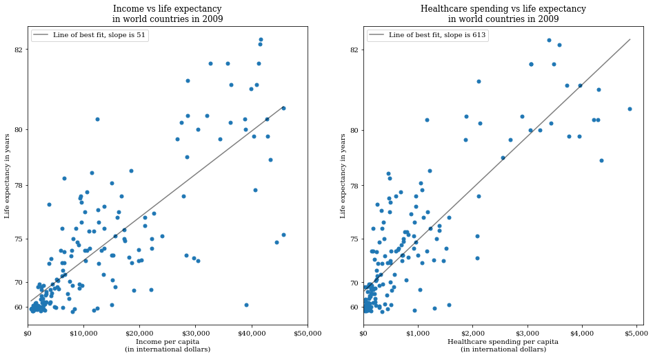

```python
# remove a few outliers first, selected by visualization of the graph.
df_gtemp1 = remove_head_and_tail(df_g, 'ic', 8, 0)
df_gtemp2 = remove_head_and_tail(df_gtemp1, 'le', 1, 0)
df_g1 = remove_head_and_tail(df_gtemp2, 'th', 1, 0)

# extract our x and y values for our graphs
y = 1.2**df_g1.loc[:,'le'].values
x1 = df_g1.loc[:,'ic'].values
x2 = df_g1.loc[:,'th'].values

fig = plt.figure(figsize=(16, 8))


##### GRAPH 1 #####
plt.subplot(1,2,1)
plt.scatter(x1, y, alpha=1, marker='.', s = 100, color=base_color)
plt.xlabel('Income per capita\n(in international dollars)')
plt.ylabel('Life expectancy in years')
plt.title('Income vs life expectancy\nin world countries in {}'.format(str(year)))
plt.xlim(0, x1.max()+500)

# find some key numbers to mark on y axis, and then convert them with our custom log base.
ytick_locs = [1.2**60, 1.2**70, 1.2**75, 1.2**78, 1.2**80, 1.2**82, 1.2**85]
base = 1.2
ytick_props = (np.log(ytick_locs) / np.log(base)).astype(int)
plt.yticks(ytick_locs, ytick_props)

# xticks will only need formatting.
xtick_locs = np.arange(0, df_g1['ic'].max()+10000, 10000)
xtick_props = ['${:,}'.format(int(v)) for v in xtick_locs]
plt.xticks(xtick_locs, xtick_props)

# draw best fit - sort isn't strictly necessary for linear bet fit but I'll use it here anyway.
m1, b1 = np.polyfit(x1, y, 1)
plt.plot(np.sort(x1), m1*np.sort(x1) + b1, \
         label='Line of best fit, slope is {}'.format(str(int(m1))), color='black', alpha = .5)
plt.legend();


##### GRAPH 2 #####
plt.subplot(1,2,2)
plt.scatter(x2, y, alpha=1, marker='.', s = 100, color=base_color)
plt.xlabel('Healthcare spending per capita\n(in international dollars)')
plt.ylabel('Life expectancy in years')
plt.title('Healthcare spending vs life expectancy\nin world countries in {}'.format(str(year)))
plt.xlim(left=0)

# find some key numbers to mark on y axis, and then convert them with our custom log base.
locs = [1.2**60, 1.2**70, 1.2**75, 1.2**78, 1.2**80, 1.2**82, 1.2**85]
base = 1.2
ticks = (np.log(locs) / np.log(base)).astype(int)
plt.yticks(locs, ticks)

# xticks will only need formatting.
xtick_locs = np.arange(0, df_g1['th'].max()+1000, 1000)
xtick_props = ['${:,}'.format(int(v)) for v in xtick_locs]
plt.xticks(xtick_locs, xtick_props)

# draw best fit - sort isn't strictly necessary for linear bet fit but I'll use it here anyway.
m2, b2 = np.polyfit(x2, y, 1)
plt.plot(np.sort(x2), m2*np.sort(x2) + b2, \
         label='Line of best fit, slope is {}'.format(str(int(m2))), color='black', alpha = .5)
plt.legend();
```

> This logarithmic transformation shows our spread a bit more clearly, but I think the logarithmic graph is the clearest in showing a layperson the main point - increased income and increased healthcare spending both correlate with increased LE, *to a point*. In my view the ability to see that ceiling effect makes the point most clearly, and also more clearly shows how similar these variables are in both *how* and also *to what extent* they are correlated with LE.

### Talk about some of the relationships you observed in this part of the investigation. How did the feature(s) of interest vary with other features in the dataset?

> Life expectancy (LE) varies quite a bit with continent, and to a lesser degree with universal healthcare (UHC) status. Almost 20 years difference exists between the LE of our highest and lowest continent, and about 10 years between the means for UHC and non-UHC countries. LE has a sharp and obvious logarithmic correlation with income and healthcare spending, although by the graphs alone neither seems obviously more correlated than the other.

> Our data also appears to show a slight bimodal form, with countries at and above an LE of 79 years tend to have a jump in income and healthcare spending. This might indicate a group of countries with top-tier healthcare, or just a significant increase in quality of life as a level of weath is reached, via access to healthy foods or other factors.

### Did you observe any interesting relationships between the other features (not the main feature(s) of interest)?

> I might have expected increased healthcare spending to have an obviously greater impact on LE than income alone, but that was not apparent from the graphs visually. A regression analysis is outside the scope of this project but may reveal a clear winner in predicting LE.

> Also noteworthy was the increased effect of continent versus UHC status - I wouldn't have necessarily assumed continent would have been a stronger indicator than location.

## Multivariate Exploration

> For our first chart, let's look at how different our graph might be with population weighting. We'll include population weighting in calculating the trend line as well.

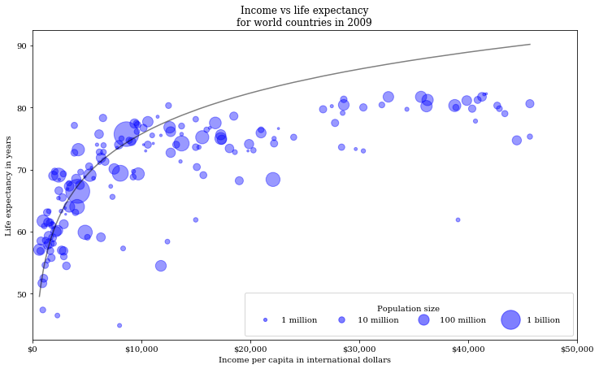

```python
fig = plt.figure(figsize=(12, 7))
y = df_g1.loc[:,'le'].values
x = df_g1.loc[:,'ic'].values
z = df_g1.pp.values

size = np.sqrt(df_g1.pp/100)

plt.scatter(x, y, alpha=0.40, marker='.', s=size, color='b')
plt.xlabel('Income per capita in international dollars')
plt.ylabel('Life expectancy in years')
plt.xlim(left=0)
plt.title('Income vs life expectancy\nfor world countries in {}'.format(str(year)))

# xticks will only need formatting.
xtick_locs = np.arange(0, df_g1['ic'].max()+5000, 10000)
xtick_props = ['${:,}'.format(int(v)) for v in xtick_locs]
plt.xticks(xtick_locs, xtick_props)

# Note: sorting is necessary to keep matplotlib from drawing multiple curves
mlog, blog = np.polyfit(np.log(x), y, 1, w=z)
plt.plot(np.sort(x), mlog*np.log(np.sort(x)) + blog, \
         label='Log line of best fit, coefficient is {}'.format(str(round(mlog,3))), color='black', alpha=.5)

labels = ["1 million", "10 million", "100 million", "1 billion"]
l1 = plt.scatter([],[], s=17, alpha = .5, color='b')
l2 = plt.scatter([],[], s=55, alpha = .5,  color='b')
l3 = plt.scatter([],[], s=173, alpha = .5, color='b')
l4 = plt.scatter([],[], s=548, alpha = .5, color='b')
leg = plt.legend([l1, l2, l3, l4], labels, ncol=4, frameon=True, fontsize=10, \
                 handlelength=2, borderpad = 1.5, handletextpad=1, \
                 title='Population size', scatterpoints = 1)
```

This chart has a clearer indication of how world *population* is distributed, as opposed to the distribution of world country count. This gets at our central question better in my opinion. Let's see if we can add UHC information to the graph as well, which might help us understand how universal healthcare might factor in.

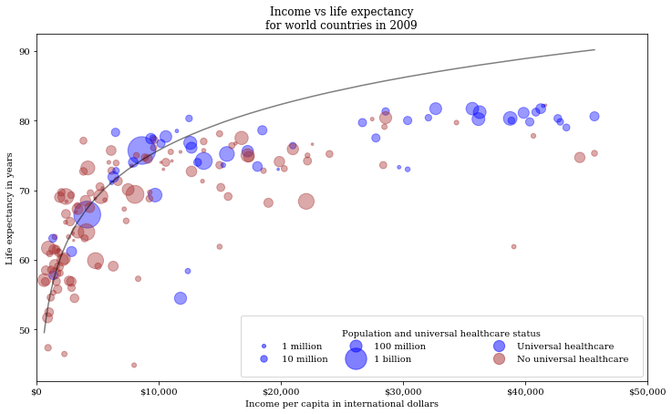

```python
fig = plt.figure(figsize=(12, 7))
y = df_g1.loc[:,'le'].values
x = df_g1.loc[:,'ic'].values
z = df_g1.pp.values

size = np.sqrt(df_g1.pp/100)

df_g1['color'] = 'brown'
df_g1.loc[df_g1.uhc==True, 'color'] = 'blue'

plt.scatter(x, y, alpha=0.40, marker='.', s=size, color=df_g1['color'])

plt.xlabel('Income per capita in international dollars')
plt.ylabel('Life expectancy in years')
plt.xlim(left=0)
plt.title('Income vs life expectancy\nfor world countries in {}'.format(str(year)))

# xticks will only need formatting.
xtick_locs = np.arange(0, df_g1['ic'].max()+5000, 10000)
xtick_props = ['${:,}'.format(int(v)) for v in xtick_locs]
plt.xticks(xtick_locs, xtick_props)

# Note: sorting is necessary to keep matplotlib from drawing multiple curves
mlog, blog = np.polyfit(np.log(x), y, 1, w=z)
plt.plot(np.sort(x), mlog*np.log(np.sort(x)) + blog, \
         label='Log line of best fit, coefficient is {}'.format(str(round(mlog,3))), color='black', alpha=.5)

labels = ["1 million", "10 million", "100 million", "1 billion", "", "", \
          "Universal healthcare", "No universal healthcare"]
l1 = plt.scatter([],[], s=17, alpha = .5, color='b')
l2 = plt.scatter([],[], s=55, alpha = .5,  color='b')
l3 = plt.scatter([],[], s=173, alpha = .5, color='b')
l4 = plt.scatter([],[], s=548, alpha = .5, color='b')
l5 = plt.scatter([],[], s=0, alpha = .5, color='b')
l6 = plt.scatter([],[], s=0, alpha = .5, color='b')
l7 = plt.scatter([],[], s=150, alpha = .5, color='b')
l8 = plt.scatter([],[], s=150, alpha = .5, color='brown')
leg = plt.legend([l1, l2, l3, l4, l5, l6, l7, l8], labels, ncol=4, frameon=True, fontsize=10, \
                 handlelength=2, borderpad = 1.5, handletextpad=1, \
                 title='Population and universal healthcare status', scatterpoints = 1)
```

This plot adds a lot to our ability to visualize the data! We can see that the blue dots, which represent countries with universal healthcare (UHC), tend to be more to the right and to the top of the graph, indicating that UHC countries are more wealthy and have higher LE than countries without (which we saw in an earlier chart as well). Next, I'd like to know if UHC makes a difference in LE per continent.

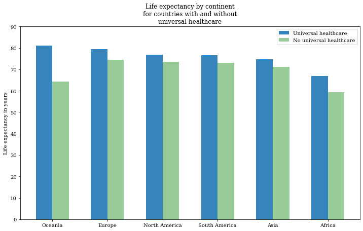

```python
continent_list = ['Oceania','Europe','North America', 'South America', 'Asia', 'Africa']

vclasses = pd.api.types.CategoricalDtype(ordered = True, categories = continent_list)
df_g1.continent = df_g1.continent.astype(vclasses)

uhc_means = df_g1.query('uhc==True').groupby('continent').le.mean()
no_uhc_means = df_g1.query('uhc==False').groupby('continent').le.mean()

fig, ax = plt.subplots(figsize=(12, 7))

ind = np.arange(uhc_means.shape[0])    # the x locations for the groups
width = 0.3                            # the width of the bars
p1 = plt.bar(ind, uhc_means, width, bottom=0, color = base_color, alpha = .9)
p2 = plt.bar(ind + width, no_uhc_means, width, bottom=0, color = 'green', alpha = .4)

ax.set_title('Life expectancy by continent\nfor countries with and without\nuniversal healthcare')
ax.set_xticks(ind + width / 2)
ax.set_xticklabels((uhc_means.index.values))
ax.set_ylabel("Life expectancy in years")
ax.set_ylim(0,90)
ax.legend((p1[0], p2[0]), ('Universal healthcare', 'No universal healthcare'))

plt.show()
```

This chart gives us an interesting look at how some continents have a lot more variation in LEs between the UHC and non-UHC countries.

### Talk about some of the relationships you observed in this part of the investigation. Were there features that strengthened each other in terms of looking at your feature(s) of interest?

> Examining some of the earlier data through the lens of UHC and non-UHC data I think strengthens the findings that income affects life expectancy - it does so regardless of UHC or non-UHC status. UHC in turn correlates with better LE regardless of continent.

### Were there any interesting or surprising interactions between features?

> I didn't expect the amount of variation between the correlation of UHC on LE in different continents. There's about a 16-year difference in means in Oceania for ex., that's huge.